# Title

## Section

### Sub-section

#### Sub-sub-section (let’s not get carried away)

This is just a normal text block with some `typewriter text` inserted.  
This is just a normal text block with some *italic text* inserted.  
This is just normal text with some **bold text** inserted.  
This is just normal text with some *bold italicised text* inserted.  
(You must end a line with two or more spaces.)

[output not shown]

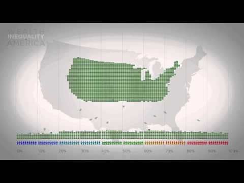

> *a quote can be generated using > space and italics*

#### Below is a code chunk

```r
## here is a code chunk
x <- c(1:30)
y <- 1.2
m <- matrix(data = x, nrow = 10, ncol = 3)
m
```

```
##       [,1] [,2] [,3]
##  [1,]    1   11   21
##  [2,]    2   12   22
##  [3,]    3   13   23
##  [4,]    4   14   24
##  [5,]    5   15   25
##  [6,]    6   16   26
##  [7,]    7   17   27
##  [8,]    8   18   28
##  [9,]    9   19   29
## [10,]   10   20   30
```

#### Below is the exact same code chunk, showing only the output

```
##       [,1] [,2] [,3]
##  [1,]    1   11   21
##  [2,]    2   12   22
##  [3,]    3   13   23
##  [4,]    4   14   24
##  [5,]    5   15   25
##  [6,]    6   16   26
##  [7,]    7   17   27
##  [8,]    8   18   28
##  [9,]    9   19   29
## [10,]   10   20   30
```

The sum of all the values of m is 465.  
The mean of all the values of x is 15.5.  
The standard deviation of x is 8.8034084.

Here is a bullet list, it requires a * and 1 space:

- First dot point
- Second dot point
  - A subpoint (requires 4 spaces, followed by * or +)
- Third dot point

Here is a numered list:

1. Item 1
2. Item 2
3. Item 3
   - Item 3a
   - Item 3b

#### Here is how you can get subscripts:

$H_0$: Some null hypothesis here.  
$H_1$: Some alternative hypothesis here.

Here is an equation: $PV=FV*(1+r)/t$
Display equation:
$$PV=FV*(1+r)^{-t}$$
Note the superscript is *<sup>something</sup>* or in an equation $R^{2}$
While we are at it, subscript is $y_{i,t}$

#### Let’s try a few real formulas:

Formula for mean is $\frac{1}{n} \sum_{i=i}^{n} x_{i}$  
Formula for fixed effects model is $y_{i,t} = \alpha_{i} + \beta x_{i,t} + \epsilon_{i,t}$

And here is an inline equation: $A = \pi*r^{2}$

#### Below is a chart. I’ve set the size and hidden the source code.

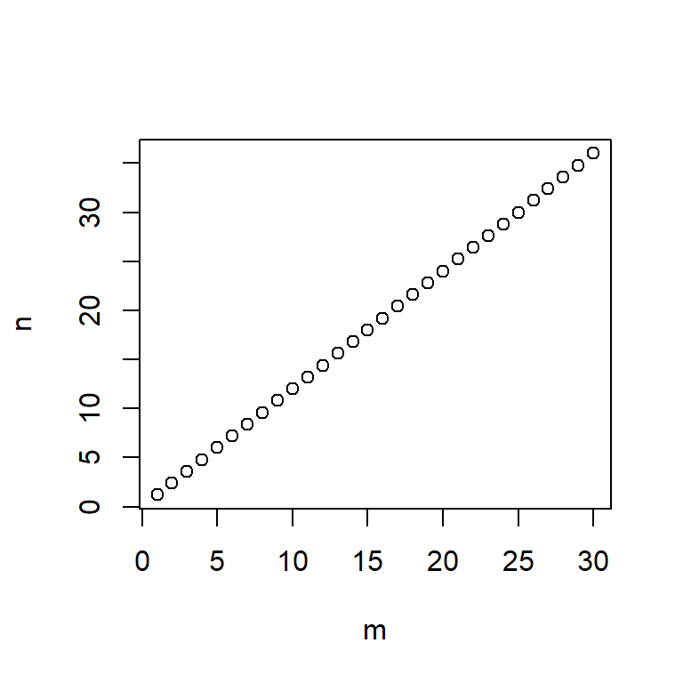

[Here is a link to ABS key indicators](http://abs.gov.au/AUSSTATS/abs@.nsf/mf/1345.0)  
[Here is a link to RBA cash rate](http://www.rba.gov.au/statistics/cash-rate)

Here is some text with a footnote.[^1]  
Here is some other text with another footnote.[^2]

#### Finally a table:

| Header | Column 1 | Column 2 | Column 3 |
| --- | --- | --- | --- |
| 1. Row | is | is | is |
| 2. Row | left | nicely | right |
| 3. Row | aligned | centered | aligned |

#### Bonus trick, a faked formatted table:

| Header | Column 1 | Column 2 | Column 3 |
| --- | --- | --- | --- |
| 1. Row | is | is | is |
| 2. Row | left | nicely | right |
| 3. Row | aligned | centered | aligned |

| Var | Sum of .. | Mean of .. | SD of .. |
| --- | --- | --- | --- |
| 1. x | 465 | 15.5 | 8.8034084 |
| 2. n | 558 | 18.6 | 10.5640901 |

[^1]: The linked footnote appears at the end of the document.
[^2]: The linked footnote appears at the end of the document.